# Data Analysis HW7

Artin Tajdini 95109983

April 28, 2018

```r
death1 = read_csv("data7/murder_suicide.csv")

death1 = death1 %>% unclass %>% data.frame()
death = death1
death[] = lapply(death1[], as.numeric)
```

# سؤال ۱

ابتدا کل داده را numeric میکنیم تا بتوان ماتریس هم بستگی را بدست آورد. سپس داده حجو را از داده حذف میکنیم(مبنای حذف بین چند ریکد نگهداشتن ستونیست که بیشترین همبیستگی را با ستون مرگ یا خودکشی دارد) سپس با کتابخانه cars نمودار همبستگی دو به دو رسم میشود (به دلیل زمانبر بودن دستور اجرا نشده است)

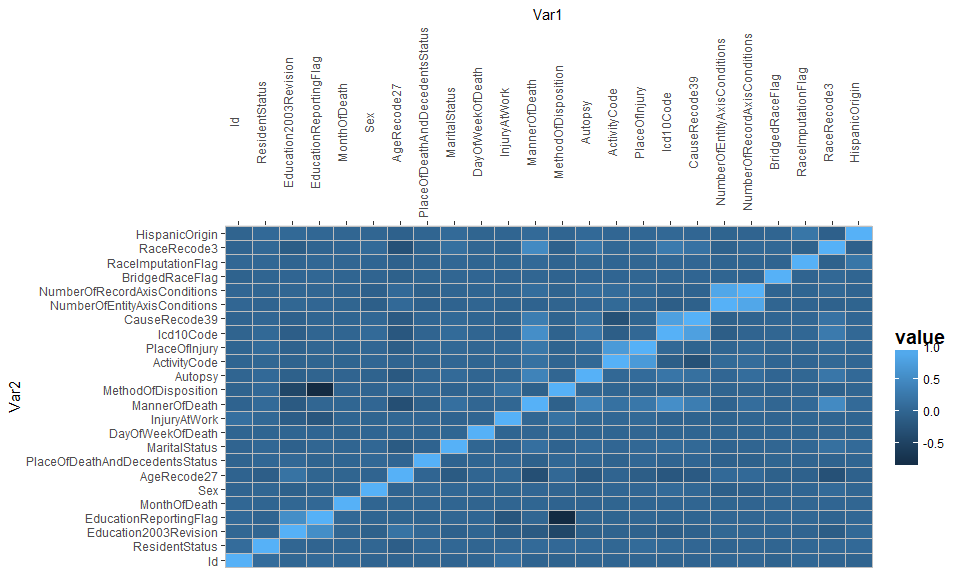

```r
death %>% select( -c(AgeRecode12, AgeRecode52, InfantCauseRecode130,
                     Age, Education1989Revision, AgeType, CurrentDataYear,
                     CauseRecode358, CauseRecode113, InfantAgeRecode22,
                     Race, RaceRecode5, HispanicOriginRaceRecode,
                     AgeSubstitutionFlag) ) -> death

cor( death, use = "complete.obs") %>%
  reshape2::melt() %>%
  ggplot(aes(Var1, Var2, fill = value)) +
  geom_tile(color = "gray") +
  theme(
    axis.text.x = element_text(angle = 90),
    panel.grid.major.x=element_blank(),
    panel.grid.minor.x=element_blank(),
    panel.grid.major.y=element_blank(),
    panel.grid.minor.y=element_blank()
  ) +
  theme(legend.title=element_text(face="bold", size=14)) +
  scale_y_discrete() +
  scale_x_discrete(expand = c(0, 0), position = "top")
```

```r
car::scatterplotMatrix(death)
```

# سوال ۲

از آنجایی که داده گسسته است پس برای بررسی مرتبط بودن از آزمون فرض chi square test of independence استفاده میکنیم و میابیم که تمام متغیر های گفته شده مرتبطند.

```r
#race
death %>% select(MannerOfDeath, RaceRecode3) %>%
  na.omit() %>%
  group_by(MannerOfDeath, RaceRecode3) %>%
  summarise(cnt = n()) %>%
  tidyr::spread(RaceRecode3, cnt) %>% .[,-1] %>%
  as.matrix() %>% chisq.test()
```

```
    Pearson's Chi-squared test

data:  .
X-squared = 15243, df = 2, p-value < 2.2e-16
```

```r
#age
death %>% select(MannerOfDeath, AgeRecode27) %>%
  na.omit() %>%
  group_by(MannerOfDeath, AgeRecode27) %>%
  summarise(cnt = n()) %>%
  tidyr::spread(AgeRecode27, cnt) %>% .[,-1] -> d

d[is.na(d)] = 0
d %>% as.matrix() %>% chisq.test()
```

```
    Pearson's Chi-squared test

data:  .
X-squared = 6761, df = 26, p-value < 2.2e-16
```

```r
#sex
death %>% select(MannerOfDeath, Sex) %>%
  na.omit() %>%
  group_by(MannerOfDeath, Sex) %>%
  summarise(cnt = n()) %>%
  tidyr::spread(Sex, cnt) %>% .[,-1] %>%
  as.matrix() %>% chisq.test()
```

```
    Pearson's Chi-squared test with Yates' continuity correction

data:  .
X-squared = 24.044, df = 1, p-value = 9.417e-07
```

```r
#edu
death %>% select(MannerOfDeath, Education2003Revision) %>%
  na.omit() %>%
  group_by(MannerOfDeath, Education2003Revision) %>%
  summarise(cnt = n()) %>%
  tidyr::spread(Education2003Revision, cnt) %>% .[,-1] %>%
  as.matrix() %>% chisq.test()
```

```
    Pearson's Chi-squared test

data:  .
X-squared = 3572.9, df = 9, p-value < 2.2e-16
```

```r
#method
death %>% select(MannerOfDeath, MethodOfDisposition) %>%
  na.omit() %>%
  group_by(MannerOfDeath, MethodOfDisposition) %>%
  summarise(cnt = n()) %>%
  tidyr::spread(MethodOfDisposition, cnt) %>% .[,-1] %>%
  as.matrix() %>% chisq.test()
```

```
    Pearson's Chi-squared test

data:  .
X-squared = 4460.4, df = 6, p-value < 2.2e-16
```

# سوال ۳

```r
death %>% mutate(murder = MannerOfDeath - 2) %>% select(-MannerOfDeath) -> death

mylogit = glm(formula = murder ~ ., data = death, family = "binomial")
summary(mylogit)
```

```
Call:
glm(formula = murder ~ ., family = "binomial", data = death)

Deviance Residuals:
    Min       1Q   Median       3Q      Max
-8.4904  -0.2474  -0.0882   0.0728   6.7138

Coefficients:
                                 Estimate Std. Error z value Pr(>|z|)
(Intercept)                    -4.368e+01  1.361e+00 -32.089  < 2e-16 ***
Id                             -1.249e-07  2.464e-08  -5.069 3.99e-07 ***
ResidentStatus                 -1.001e-01  3.255e-02  -3.075 0.002106 **
Education2003Revision          -1.753e-01  1.267e-02 -13.838  < 2e-16 ***
EducationReportingFlag          4.082e-01  1.300e-01   3.141 0.001685 **
MonthOfDeath                    7.001e-03  5.562e-03   1.259 0.208152
Sex                            -4.849e-01  4.506e-02 -10.760  < 2e-16 ***
AgeRecode27                    -6.973e-02  5.589e-03 -12.476  < 2e-16 ***
PlaceOfDeathAndDecedentsStatus -1.344e-01  9.091e-03 -14.785  < 2e-16 ***
MaritalStatus                   8.218e-02  2.052e-02   4.006 6.18e-05 ***
DayOfWeekOfDeath                7.570e-03  9.388e-03   0.806 0.420052
InjuryAtWork                    1.579e-01  5.699e-02   2.770 0.005600 **
MethodOfDisposition            -7.260e-02  1.912e-02  -3.797 0.000147 ***
Autopsy                         1.372e+00  4.361e-02  31.453  < 2e-16 ***
ActivityCode                    2.621e-01  4.672e-03  56.105  < 2e-16 ***
PlaceOfInjury                   1.559e-01  2.509e-03  62.114  < 2e-16 ***
Icd10Code                       2.152e-01  2.988e-03  72.015  < 2e-16 ***
CauseRecode39                  -2.925e-01  4.284e-02  -6.827 8.69e-12 ***
NumberOfEntityAxisConditions   -2.412e-01  3.647e-02  -6.613 3.76e-11 ***
NumberOfRecordAxisConditions    4.324e-01  3.695e-02  11.703  < 2e-16 ***
BridgedRaceFlag                -1.527e-01  1.760e-01  -0.867 0.385732
RaceImputationFlag              3.119e-01  6.796e-02   4.589 4.45e-06 ***
RaceRecode3                     7.256e-01  2.365e-02  30.683  < 2e-16 ***
HispanicOrigin                  1.629e-03  2.252e-04   7.230 4.82e-13 ***
---
Signif. codes:  0 '***' 0.001 '**' 0.01 '*' 0.05 '.' 0.1 ' ' 1

(Dispersion parameter for binomial family taken to be 1)

    Null deviance: 71216  on 59978  degrees of freedom
Residual deviance: 18469  on 59955  degrees of freedom
AIC: 18517

Number of Fisher Scoring iterations: 10
```

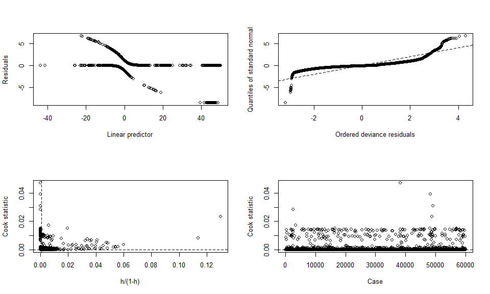

```r
library(boot)
glm.diag.plots(mylogit, glmdiag = glm.diag(mylogit))
```

```r
rdeath = death %>% select( -c(MonthOfDeath, DayOfWeekOfDeath, BridgedRaceFlag) )
mylogit = glm(formula = murder ~ ., data = rdeath, family = binomial(link = 'logit'))

library(ResourceSelection)
hoslem.test(death$murder, fitted(mylogit))
```

```
    Hosmer and Lemeshow goodness of fit (GOF) test

data:  death$murder, fitted(mylogit)
X-squared = 2234.2, df = 8, p-value < 2.2e-16
```

# سوال ۴

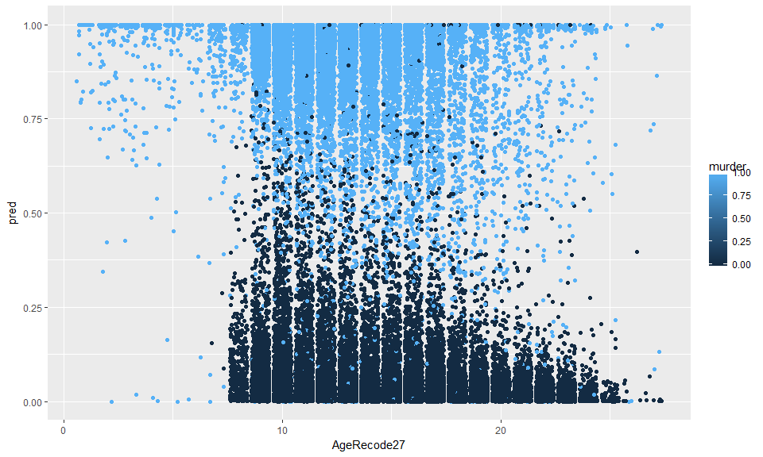

```r
death %>% mutate(pred = fitted(mylogit)) %>%
  ggplot(aes(x = AgeRecode27, y = pred, col = murder)) + geom_jitter()
```

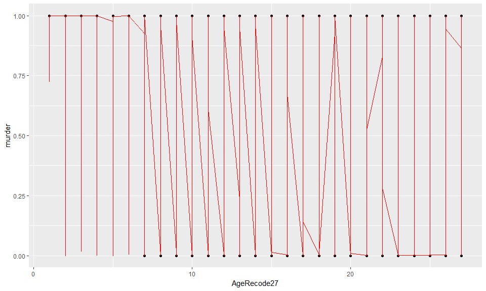

```r
ggplot(data = death %>% mutate(pred = predict(mylogit, type = 'response')), aes(x = AgeRecode27, y = murder)) + geom_point() +
  geom_line(aes(x = AgeRecode27, y = pred), color = 'red', size = 0.3)
```

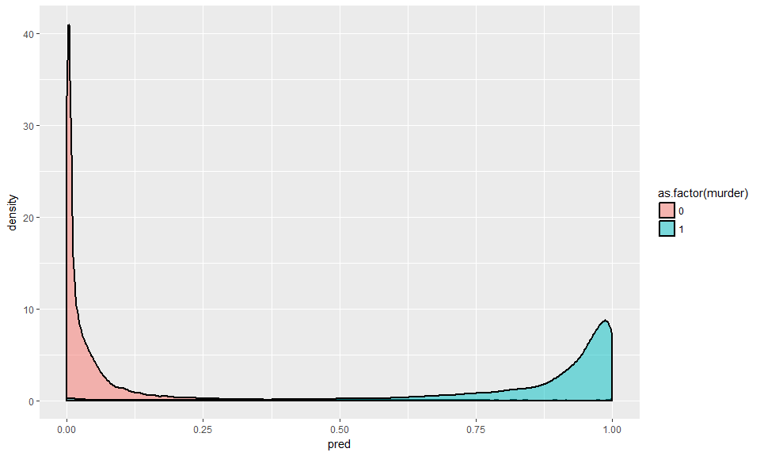

```r
ggplot( data = death %>% mutate(pred = fitted(mylogit)), aes( pred, fill = as.factor(murder))) +
  geom_density(size = 1, alpha = 0.5)
```

# سوال ۵

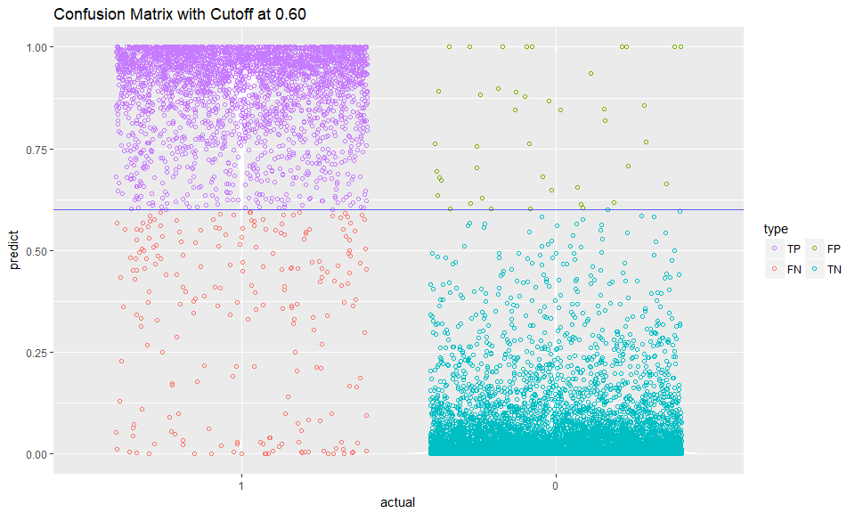

```r
index = sample(x= 1:nrow(rdeath),size = 0.8*nrow(rdeath),replace = F)
train = rdeath[index,]
test =  rdeath[-index,]
model_glm = glm(murder ~ ., data = train, family = "binomial")
# prediction
train$prediction = predict( model_glm, newdata = train, type = "response" )
test$prediction  = predict( model_glm, newdata = test , type = "response" )


cm_info = ConfusionMatrixInfo( data = test, predict = "prediction",
                               actual = "murder", cutoff = .6 )
cm_info$plot
```

```r
TP =  sum((test$prediction > 0.5) & (test$murder == 1))
TP
```

```
[1] 3170
```

```r
TN = sum((test$prediction < 0.5) & (test$murder == 0))
TN
```

```
[1] 8588
```

```r
FP = sum((test$prediction > 0.5) & (test$murder == 0))
FP
```

```
[1] 79
```

```r
FN = sum((test$prediction < 0.5) & (test$murder == 1))
FN
```

```
[1] 159
```

```r
P = TP + FP
P
```

```
[1] 3249
```

```r
N =  TN + FN
N
```

```
[1] 8747
```

```r
ACC = (TP+TN)/(P+N)
ACC
```

```
[1] 0.9801601
```

```r
FPR = 1- TN/N
FPR
```

```
[1] 0.01817766
```

```r
TPR = TP/P
TPR
```

```
[1] 0.9756848
```

# سوال ۶

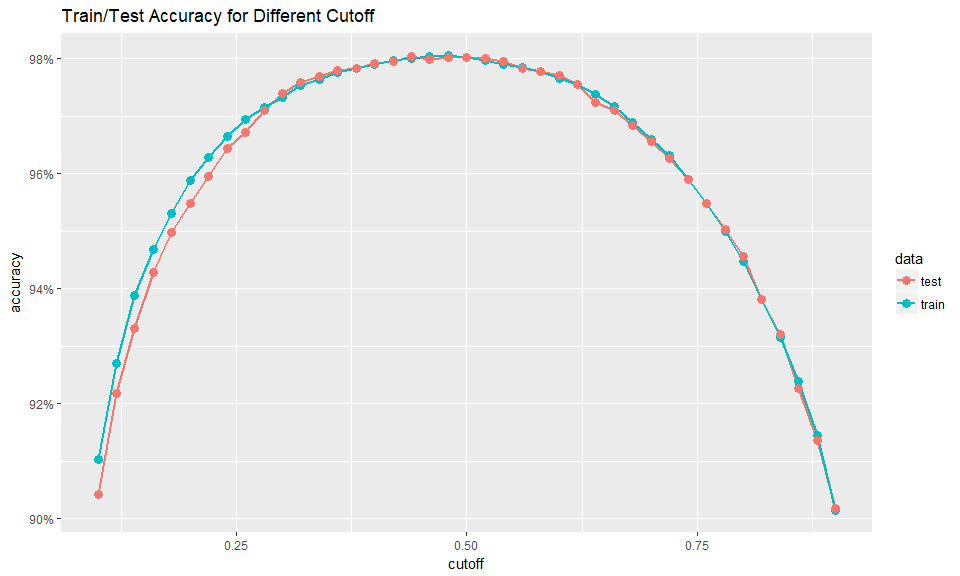

```r
accuracy_info = AccuracyCutoffInfo( train = train, test = test, predict = "prediction", actual = "murder" )
accuracy_info$plot
```

# سوال ۷

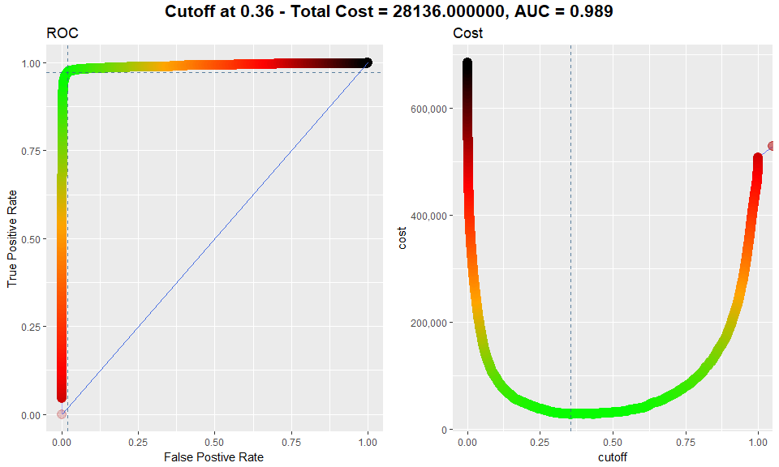

```r
cost_fp = FP; cost_fn = FN
roc_info = ROCInfo( data = cm_info$data, predict = "predict",
                    actual = "actual", cost.fp = cost_fp, cost.fn = cost_fn )
grid.draw(roc_info$plot)
```

# سوال ۸

به علت حجم بالا پکیج کد آنرا بدون اجرا کردن نشان میدهیم!!!

```r
library(h2o)
h2o.init()
hdeath = as.h2o(rdeath)
c2 = colnames(rdeath)
chglm = h2o.glm(y = "murder", x= c2[c2 != "murder"],
                training_frame = hms, family="binomial",nfolds = 5)
chglm
```

# سوال ۹

بله اگر دیتا به اندازه کافی باشد تا خطای مدلمان به حد کافی کم شود میتوانیم به خروجی مدل اتکا کنیم اگرچه در این مورد باید پارامتر قطع بطوری باشد که خطای نوع اول(خودکشی را قتل تشخیص دادن) کمینه شود